## The Data

We will begin with an example of simple logistic regression with a sample of the [Western Collaborative Group Study](https://clinicaltrials.gov/ct2/show/NCT00005174). This study began in 1960 with 3154 men ages 39-59, who were employed in one of 11 California based companies. They were followed until 1969 during this time, 257 of these men developed coronary heart disease (CHD). You can read this data in with the code below. [Lab 4 Markdown](https://php-1511-2511.github.io/labs/lab4.Rmd)

## Reading in the Data

```r
library(haven)
wcgs <- read_dta("wcgs2.dta")
wcgs <- wcgs[, -16]
```

## The Variables

| Name | Description |
| --- | --- |
| id | Subject identification number |
| age | Age in years |
| height | Height in inches |
| weight | Weight in lbs. |
| sbp | Systolic blood pressure in mm |
| dbp | Diastolic blood pressure in mm Hg |
| chol | Fasting serum cholesterol in mm |
| behpat | Behavior |
|  | 1 = A1 |
|  | 2 = A2 |
|  | 3 = B3 |
|  | 4 = B4 |
| ncigs | Cigarettes per day |
| dibpat | Behavior |
|  | 1 = type A |
|  | 2 = type B |
| chd69 | Coronary heart disease |
|  | 1 = Yes |
|  | 0 = no |
| typechd | Type of CHD |
|  | 1 = myocardial infarction or death |
|  | 2 = silent myocardial infarction |
|  | 3 = angina perctoris |
| time169 | Time of CHD event or end of follow-up |
| arcus | Arcus senilis |
|  | 0 = absent |
|  | 1 = present |
| bmi | Body Mass Index |

1. Begin by exploring the data and relationships further. What kind of relationships do you notice with outcome of Coronary Heart Disease (CHD)? Make sure to use appropriate tables, graphs or summaries.

**For continuous covariates, we can explore their relationship with CHD by using boxplots. For categorical covariates, we can create contingency tables by `table` function, in order to explore their relationship with CHD.**

```r
numeric <- c("age","height","weight","sbp","dbp","chol","ncigs","bmi","time169")
knitr::kable(summary(wcgs[numeric]))
category <- c("behpat","dibpat","chd69","typchd69","arcus")
apply(wcgs[category],2,table)
```

[output not shown]

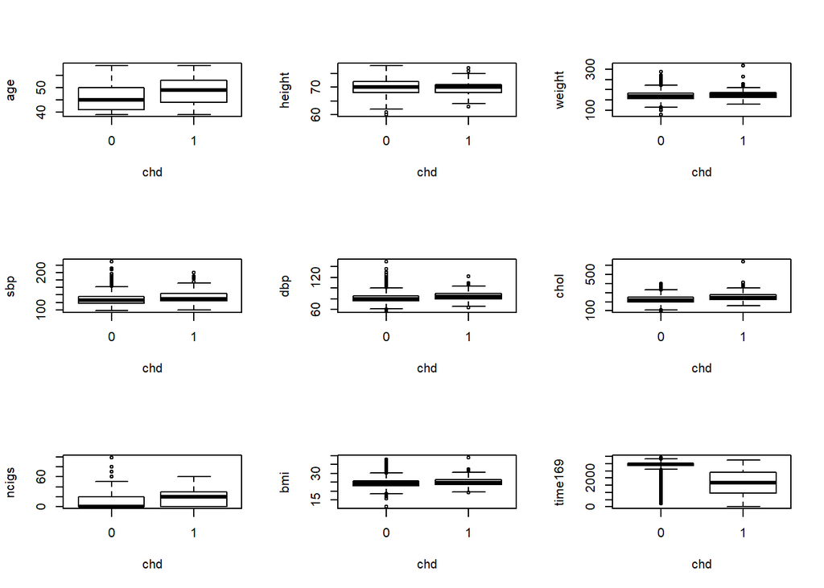

```r
#plot for numerical variables vs. CHD
library(ggplot2)
par(mfrow = c(3,3))
for (var in numeric) {
  boxplot(as.formula(paste0(var,"~chd69")), data = wcgs, xlab = "chd", ylab = var)
}
```

```r
#tables for categorical variable vs. CHD
for (var in category) {
  print(table(wcgs[c("chd69",var)]))
}
```

```
##      behpat
## chd69    1    2    3    4
##     0  234 1177 1155  331
##     1   30  148   61   18
##      dibpat
## chd69    0    1
##     0 1486 1411
##     1   79  178
##      chd69
## chd69    0    1
##     0 2897    0
##     1    0  257
##      typchd69
## chd69    0    1    2    3
##     0 2897    0    0    0
##     1    0  135   71   51
##      arcus
## chd69    0    1
##     0 2058  839
##     1  153  102
```

2. Create logistic regressions with the following variables:
   - `age`
   - `bmi`
   - `sbp`
   - `dbp`
   - `behpat`
   - `ncigs`
   - `dibpat`
   - `arcus`

   Create a table with these univariate regressions. Interpret them.

```r
#turn categorical variables into factors
library(tidyverse)
wcgs<-wcgs %>% mutate(behpat=factor(behpat,levels = c(1,2,3,4),labels=c("A1","A2","B3","B4"))) %>%
           mutate(dibpat=factor(dibpat,levels=c(1,0),labels=c("A","B")))%>%
           mutate(chd69=as.factor(chd69))%>%
           mutate(typchd69=as.factor(typchd69))%>%
           mutate(arcus=as.factor(arcus))
```

```r
library(broom)
result <- c()
for (var in c("age","bmi","sbp","dbp","behpat","ncigs","dibpat","arcus")) {
  f <- as.formula(paste0("chd69~", var))
  m <- glm(f, data = wcgs, family = binomial(link = "logit"))
  r <- tidy(m, exponentiate = T, conf.int = T)[-1,-c(3,4)]
  result <- rbind(result,r)
}
result
```

```
##        term  estimate      p.value  conf.low conf.high
## 2       age 1.0772619 4.557900e-11 1.0536639 1.1014329
## 21      bmi 1.0879302 4.746882e-04 1.0372496 1.1401466
## 22      sbp 1.0270301 3.727669e-13 1.0196129 1.0344164
## 23      dbp 1.0341298 2.007131e-08 1.0219629 1.0462403
## 24 behpatA2 0.9807986 9.273491e-01 0.6553361 1.5123703
## 3  behpatB3 0.4119481 1.529395e-04 0.2624012 0.6593955
## 4  behpatB4 0.4241692 5.685465e-03 0.2270284 0.7715971
## 25    ncigs 1.0234915 9.223399e-09 1.0153544 1.0315901
## 26  dibpatB 0.4214201 7.118661e-10 0.3186990 0.5525801
## 27   arcus1 1.6352801 2.483353e-04 1.2542942 2.1240618
```

**The coefficient interpretation is different for continuous covariate and categorical covariate. For a continuouse covariate, its exponentiated coefficient can be interpreted in following ways:**

**Take `age` as an example:**

**$\cdot$ If there are 2 people who differ in age by one year the older person would on average have an odds of CHD 1.077 times that of the younger.**

**$\cdot$ On average a person has an odds of CHD 0.077 higher than someone a year younger.**

**$\cdot$ On average a person has an odds of CHD 7.726% higher than someone a year younger.**

**For a categorical covariate, its exponentiated coefficeint can be interpreted in following ways:**

**Take `arcus` as an example:**

**$\cdot$ On average a person with Arcus Senilis present has an odds of CHD 1.635 times that of the odds of CHD for another person with absence of Arcus Senilis.**

**$\cdot$ On average a person with Arcus Senilis present has an odds of CHD 63.528% higher than the odds of CHD for another person with absence of Arcus Senilis.**

3. Consider a multiple with all of the above variables.

```r
table(wcgs$dibpat,wcgs$behpat)
m1<-glm(chd69 ~ age+bmi+sbp+dbp+behpat+dibpat+ncigs+arcus, data = wcgs, family = binomial(link = "logit"))

#m2<-glm(chd69 ~ age+bmi+sbp+dbp+dibpat+behpat+ncigs+arcus, data = wcgs, family = binomial(link = "logit"))

tidy(m1, exponentiate = T, conf.int = T)[,-c(3,4)]
#tidy(m2, exponentiate = T, conf.int = T)
```

```
##
##       A1   A2   B3   B4
##   A  264 1325    0    0
##   B    0    0 1216  349
##           term     estimate      p.value     conf.low   conf.high
## 1  (Intercept) 6.644406e-05 1.584605e-24 1.035371e-05 0.000415262
## 2          age 1.060567e+00 1.170574e-06 1.035709e+00 1.086046836
## 3          bmi 1.068028e+00 1.151964e-02 1.014586e+00 1.123732275
## 4          sbp 1.019573e+00 2.095482e-03 1.006924e+00 1.032132283
## 5          dbp 1.000659e+00 9.498950e-01 9.802821e-01 1.021435331
## 6     behpatA2 1.039891e+00 8.585570e-01 6.851928e-01 1.624144766
## 7     behpatB3 5.039283e-01 4.609561e-03 3.161822e-01 0.818601770
## 8     behpatB4 5.664717e-01 7.351574e-02 2.991780e-01 1.046538828
## 9        ncigs 1.022909e+00 6.299268e-08 1.014498e+00 1.031305046
## 10      arcus1 1.378632e+00 2.282318e-02 1.043367e+00 1.814703356
```

```
a. Comment on the changes you see in coefficients from the univariate to multiple regression model.
```

```
b. Pick the 3 most significant coefficients and interpret them.
```

**Based on p-values, we choose `age`, `ncigs` and `sbp`` as 3 most significant coefficients.**

**Take `age` as an example: On average a person has an odds of CHD 0.060 higher than someone a year younger, conditioning on all other covariates.**

4. What is the log odds of CHD for a 65 year old with bmi of 36, sbp of 136, dbp 78, behpat A2, ncigs=3, dibpat Type B and No Arcus.

**For prediction, we need to first create a new data entry, then use `predict` function with the new dataset to predict the log odds.**

```r
new_input <- data.frame(age = 65,bmi = 36, sbp = 136,dbp = 78,behpat = "A2",ncigs = 3,arcus = factor(0), dibpat = "B")
log_odds <- predict(m1,newdata=new_input)
log_odds
```

```
##          1
## -0.6328796
```

5. What is the probability of CHD for a 65 year old with bmi of 36, sbp of 136, dbp 78, behpat A2, ncigs=3, dibpat Type B and No Arcus.

```r
p <- exp(log_odds)/exp(1+log_odds)
p
```

```
##         1
## 0.3678794
```